# Notebook Exercises Chapter 2

Max Beauchez

**2E1.** Which of the expressions below correspond to the statement: *the probability of rain on Monday*?

1. Pr(rain)
2. Pr(rain|Monday)
3. Pr(Monday|rain)
4. Pr(rain, Monday)/Pr(Monday)

2: Pr(rain|Monday) and 4: Pr(rain, Monday)/Pr(Monday)

**2E2.** Which of the following statements corresponds to the expression: Pr(Monday|rain)?

1. The probability of rain on Monday.
2. The probability of rain, given that it is Monday.
3. The probability that it is Monday, given that it is raining.
4. The probability that it is Monday and that it is raining.

3: The probability that it is Monday, given that it is raining

**2E3.** Which of the expressions below correspond to the statement: *the probability that it is Monday, given that it is raining*? 1. Pr(Monday|rain)

2. Pr(rain|Monday)
3. Pr(rain|Monday)Pr(Monday)
4. Pr(rain|Monday)Pr(Monday)/Pr(rain)
5. Pr(Monday|rain)Pr(rain)/Pr(Monday)

1: Pr(Monday|rain) and 4: Pr(Monday|Rain)=Pr(Monday)*Pr(rain|Monday)/Pr(rain)

**2E4.** The Bayesian statistician Bruno de Finetti (1906-1985) began his 1973 book on probability theory with the declaration: “PROBABILITY DOES NOT EXIST.” The capitals appeared in the original, so I imagine de Finetti wanted us to shout this statement. What he meant is that probability is a device for describing uncertainty from the perspective of an observer with limited knowledge; it has no objective reality. Discuss the globe tossing example from the chapter, in light of this statement. What does it mean to say “the probability of water is 0.7”?

A certain unknown proportion of the surface of the globe consists of water. The probability of water is 0.7 means that we’ve estimated this proportion to be 70% (0.7). We will only ever observe land or water.

**2M1.** Recall the globe tossing model from the chapter. Compute and plot the grid approximate posterior distribution for each of the following sets of observations. In each case, assume a uniform prior for *p*.

1. W, W, W
2. W, W, W, L
3. L, W, W, L, W, W, W

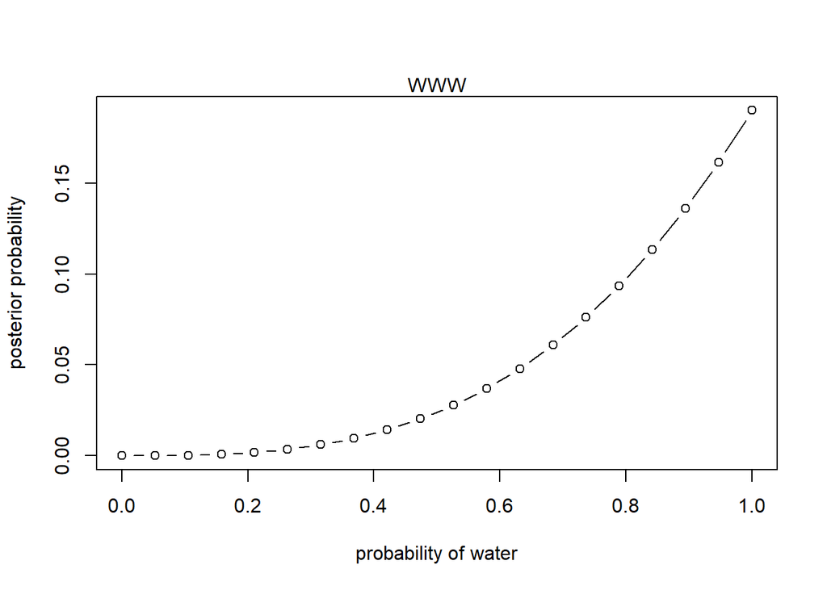

```r
p_grid <- seq(from=0, to=1, length.out=20)
prior <- rep(1, 20)
likelihood <- dbinom(3, size=3, prob=p_grid)
unstd.posterior <- likelihood*prior
std.posterior <- unstd.posterior/sum(unstd.posterior)
plot(p_grid, std.posterior, type="b", xlab="probability of water", ylab="posterior probability")
mtext("WWW")
```

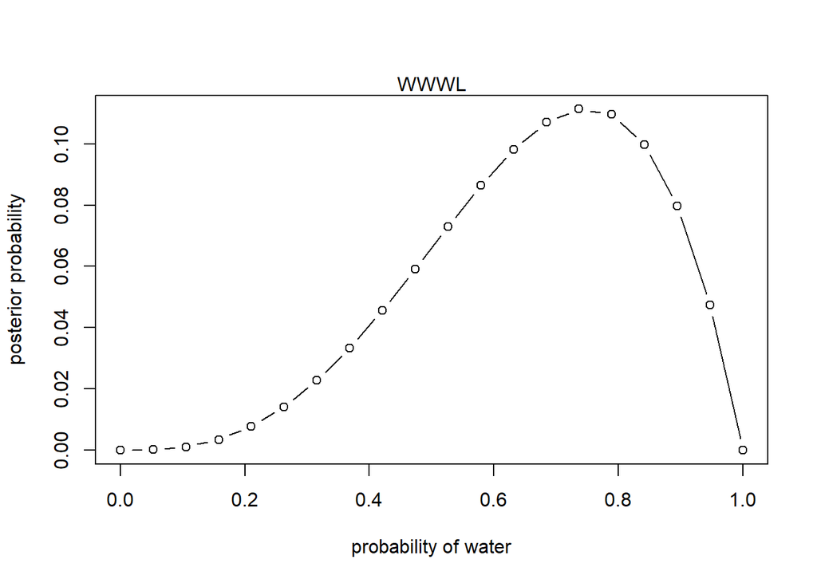

```r
likelihood <- dbinom(3, size=4, prob=p_grid)
unstd.posterior <- likelihood*prior
std.posterior <- unstd.posterior/sum(unstd.posterior)
plot(p_grid, std.posterior, type="b", xlab="probability of water", ylab="posterior probability")
mtext("WWWL")
```

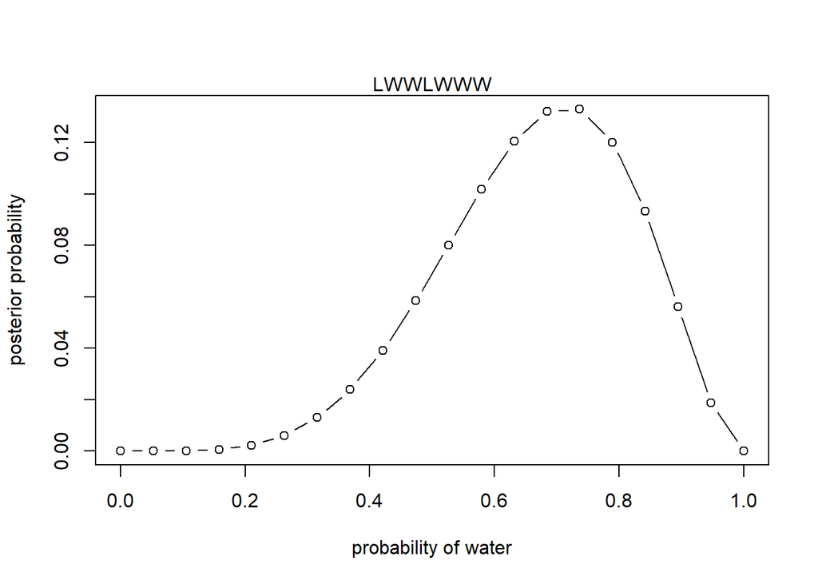

```r
likelihood <- dbinom(5, size=7, prob=p_grid)
unstd.posterior <- likelihood*prior
std.posterior <- unstd.posterior/sum(unstd.posterior)
plot(p_grid, std.posterior, type="b", xlab="probability of water", ylab="posterior probability")
mtext("LWWLWWW")
```

**2M2.** Now assume a prior for *p* that is equal to zero when $p < 0.5$ and is a positive constant when $p\geq 0.5$. Again compute and plot the grid approximate posterior distribution for each of the sets of observations in the problem just above.

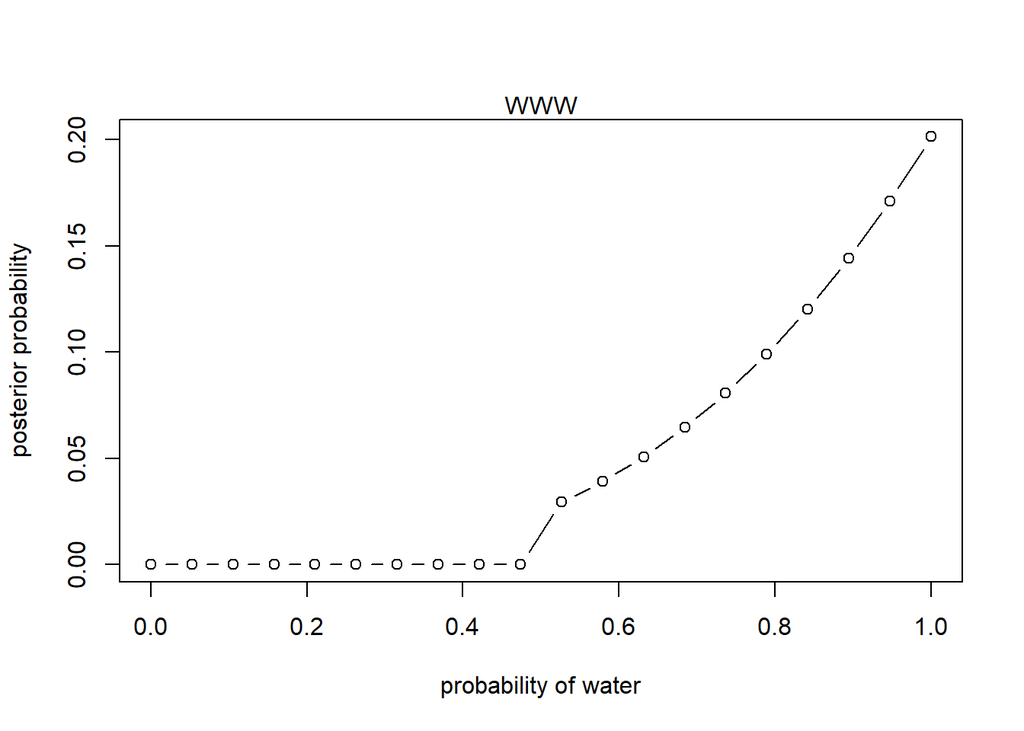

```r
p_grid <- seq(from=0, to=1, length.out=20)
prior <- ifelse(p_grid < 0.5, 0, 1)
likelihood <- dbinom(3, size=3, prob=p_grid)
unstd.posterior <- likelihood*prior
std.posterior <- unstd.posterior/sum(unstd.posterior)
plot(p_grid, std.posterior, type="b", xlab="probability of water", ylab="posterior probability")
mtext("WWW")
```

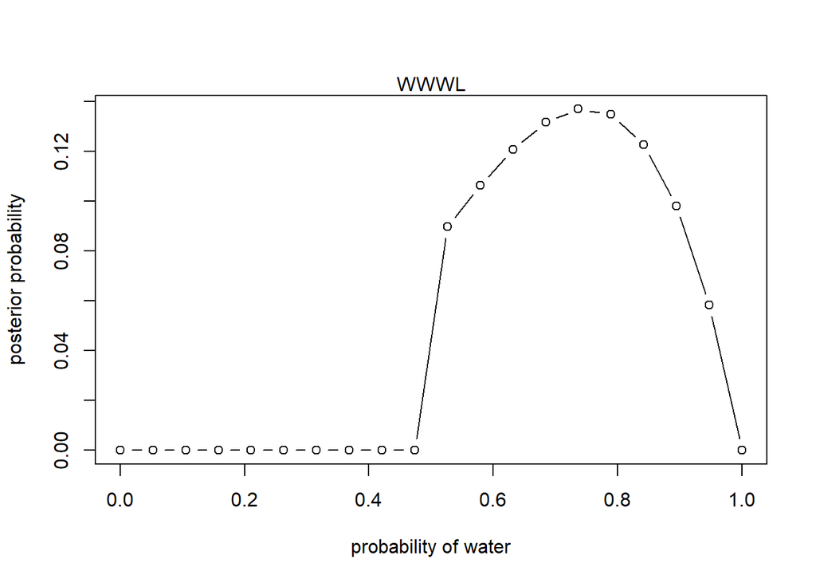

```r
likelihood <- dbinom(3, size=4, prob=p_grid)
unstd.posterior <- likelihood*prior
std.posterior <- unstd.posterior/sum(unstd.posterior)
plot(p_grid, std.posterior, type="b", xlab="probability of water", ylab="posterior probability")
mtext("WWWL")
```

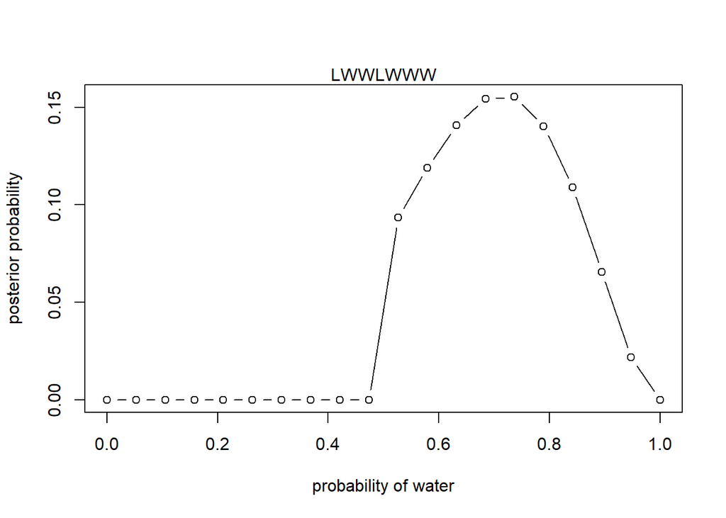

```r
likelihood <- dbinom(5, size=7, prob=p_grid)
unstd.posterior <- likelihood*prior
std.posterior <- unstd.posterior/sum(unstd.posterior)
plot(p_grid, std.posterior, type="b", xlab="probability of water", ylab="posterior probability")
mtext("LWWLWWW")
```

**2M3.** Suppose there are two globes, one for Earth and one for Mars. The Earth globe is 70% covered in water. The Mars globe is 100% land. Further suppose that one of these globes—you don’t know which—was tossed in the air and produced a “land” observation. Assume that each globe was equally likely to be tossed. Show that the posterior probability that the globe was the Earth, conditional on seeing “land” (Pr(Earth|land)), is 0.23.